# Week 2 Assignment

Ricardo de la Torre

1/6/2020

## Introduction

This is the Markdown document for the Week 2 Assignment on the Reproducible Research for Data Science.

## Step 1: What is mean total number of steps taken per day?

First, we load the data into a variable, omitting the NA information.

```r
activity <- read.csv("activity.csv")

tidy_activity <- na.omit(activity)
```

```r
library(dplyr)

new_activity <- tidy_activity %>%
   group_by(date) %>%
   summarise(SumSteps = sum(steps))
```

Using the ggplot2 system, we generate the histogram for the total number of steps per day.

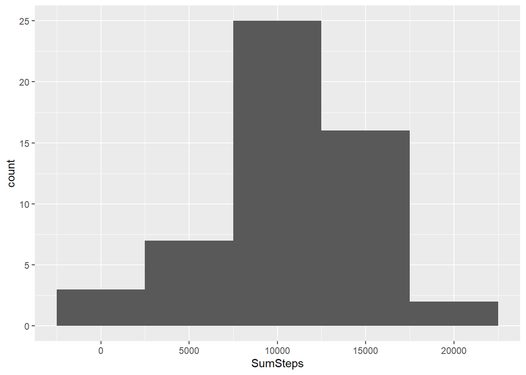

```r
library(ggplot2)

ggplot(new_activity, aes(SumSteps)) + geom_histogram(binwidth = 5000)
```

Finally, we calculate the mean and median of the total of steps

```r
#disable scientific notation
options(scipen=999)

meanStep <- mean(new_activity$SumSteps)
medianStep <- median(new_activity$SumSteps)
```

- The **mean** total number of steps taken per day: *10766.1886792*
- The **median** total number of steps taken per day: *10765*

## Step 2: What is the average daily activity pattern?

First, we have to get the information asked by twisting the activity data in a proper way. As requested, we have to plot the data with the x-axis as 5-minute interval and the average number of steps taken across all days in the y-axis.

```r
avg_activity <- tidy_activity %>%
   group_by(interval) %>%
   summarise(AvgSteps = mean(steps))
```

The time series plot resulting with this information is the stated below, plotted using ggplot

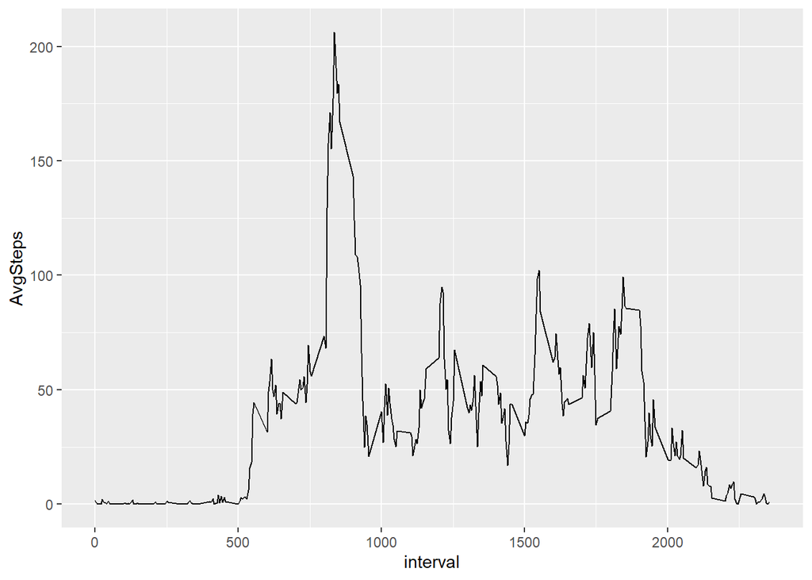

```r
ggplot(avg_activity, aes(interval, AvgSteps)) + geom_line()
```

Which 5-minute interval, on average across all the days in the dataset, contains the maximum number of steps?

```r
maxIdx = which.max(avg_activity$AvgSteps)
maxInterval = avg_activity[maxIdx, 'interval']
maxAvgStep = avg_activity[maxIdx, 'AvgSteps']
```

- On average across all the days in the dataset, **835** 5-minute interval contains maximum number of steps (*206.1698113* steps)

## Step 3: Imputing missing values

1. Calculate and report the total number of missing values in the dataset (i.e. the total number of rows with NAs)

```r
totalNA = sum(is.na(activity$steps))
```

- The total number of missing values in the dataset: **2304**
2. Devise a strategy for filling in all of the missing values in the dataset. The strategy does not need to be sophisticated. For example, you could use the mean/median for that day, or the mean for that 5-minute interval, etc.

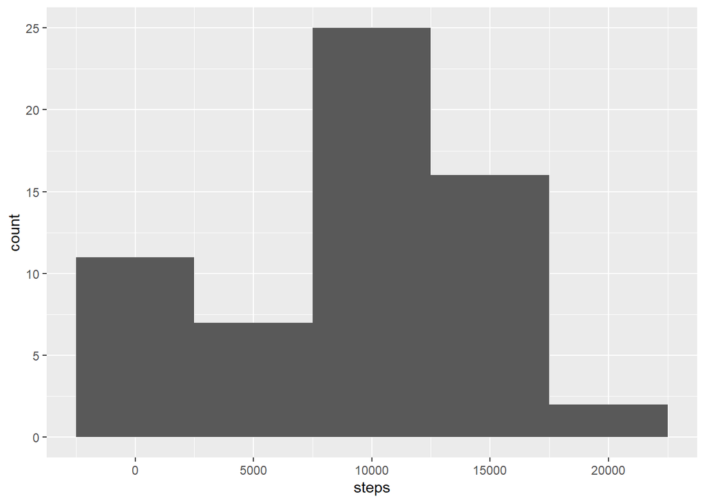

```r
#get the NA index
naIdx = which(is.na(activity$steps))
naInterval = activity[naIdx, 3]

#get the corrosponding intervale
fillSteps = sapply(naInterval, function(x) { avg_activity[(avg_activity$interval==x), 2]})

#create a new dataset that is equal to the orginal dataset
# BUT with the missing data filled in
dataNew = activity
dataNew[naIdx, 'steps'] = fillSteps

#fill in missing data
#again, calculate the average of steps w.r.t. the time interval
sumStepNew = aggregate(steps~date, dataNew, sum)

#plot graph

ggplot(sumStepNew, aes(steps)) + geom_histogram(binwidth = 5000)
```

We then calculate the mean and median values with the addition of the new missing values

```r
#calculate the mean and median total number of steps taken per day
meanStepNew = mean(sumStepNew$steps)
medianStepNew = median(sumStepNew$steps)
```

- The **mean** total number of steps taken per day: *9419.08073*
- The **median** total number of steps taken per day: *10395*

## Step 4: Are there differences in activity patterns between weekdays and weekends?

First, we need to create a new factor variable in the dataset with two levels – “weekday” and “weekend” indicating whether a given date is a weekday or weekend day.

```r
dataNew$date = as.Date(as.character(dataNew$date), "%Y-%m-%d")

dataNew['dateIs'] = factor(sapply(dataNew$date, function(x){ if (weekdays(x) == "domingo" | weekdays(x) == "sabado") { "weekend" } else { "weekday"} }))

#calculate the average of steps w.r.t. the time interval and dateIs
avgStepDateIs = aggregate(steps~interval + dateIs, mean, data=dataNew)
```

Then, we make a panel plot containing a time series plot (i.e. type = “l”) of the 5-minute interval (x-axis) and the average number of steps taken, averaged across all weekday days or weekend days (y-axis). We do this using lattice to look like the one given as example.

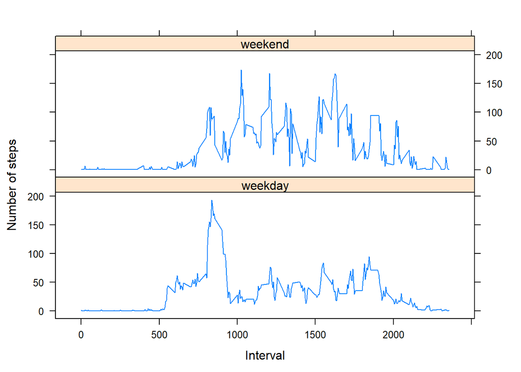

```r
library(lattice)

xyplot( steps ~ interval | dateIs, data = avgStepDateIs, type="l", layout=c(1,2), xlab="Interval", ylab="Number of steps")
```